# bike_sharing_report

Mila

2022-08-04

## Setup

Install and load the necessary packages.

```r
library(tidyverse)  #helps wrangle data
library(lubridate)  #helps wrangle date attributes
```

```r
library(ggplot2)  #helps visualize data
```

Check your current directory.

```r
getwd()
```

```
## [1] "/Users/mila/Desktop/final_project"
```

Change your working directory if necessary with setwd(“new_directory”).

## Data Collection

I have previously cleaned and combined data from 12 months into four quarters. Let’s combine now that data into one year.

```r
q1 <- read_csv("q1.csv")
q2 <- read_csv("q2.csv")
q3 <- read_csv("q3.csv")
q4 <- read_csv("q4.csv")
yearly_trips <- bind_rows(q1,q2,q3,q4)
```

Check the column names and data types with

```r
sapply(yearly_trips, typeof)
```

```
##            ride_id      rideable_type         started_at           ended_at
##        "character"        "character"        "character"        "character"
## start_station_name   start_station_id   end_station_name     end_station_id
##        "character"        "character"        "character"        "character"
##      member_casual
##        "character"
```

I have previously deleted unnecessary rows with

```r
yearly_trips <- yearly_trips %>%
  select(-c(start_lat, start_lng, end_lat, end_lng))
```

Add the columns that will list date, month, day of the week, and year of the ride. This will make data aggregation easier.

```r
yearly_trips$date <- as.Date(yearly_trips$started_at)
yearly_trips$month <- format(as.Date(yearly_trips$date), "%m")
yearly_trips$day <- format(as.Date(yearly_trips$date), "%d")
yearly_trips$year <- format(as.Date(yearly_trips$date), "%Y")
yearly_trips$day_of_week <- format(as.Date(yearly_trips$date), "%A")
```

Add a ride_length column to the data.

```r
yearly_trips$ride_length <- difftime(yearly_trips$ended_at,yearly_trips$started_at)
```

There are going to be rows with negative ride lengths. Delete them with

```r
yearly_trips <- yearly_trips[!(yearly_trips$ride_length<=0),]
```

You can also get rid of some rows containing blank or N/A values with

```r
yearly_trips <- yearly_trips[!(is.na(yearly_trips$start_station_id) | yearly_trips$start_station_id==""), ]
```

## Aggregation and Visualization

Make a new dataset that aggreates weekday and membership type.

```r
trips_weekday <- yearly_trips %>%
  mutate(weekday = wday(started_at, label = TRUE)) %>%
  group_by(member_casual, weekday) %>%
  summarise(number_of_rides = n()
            ,average_duration = mean(ride_length)) %>%
  arrange(member_casual, weekday)
```

Visualize the number of rides by rider type depending on weekday.

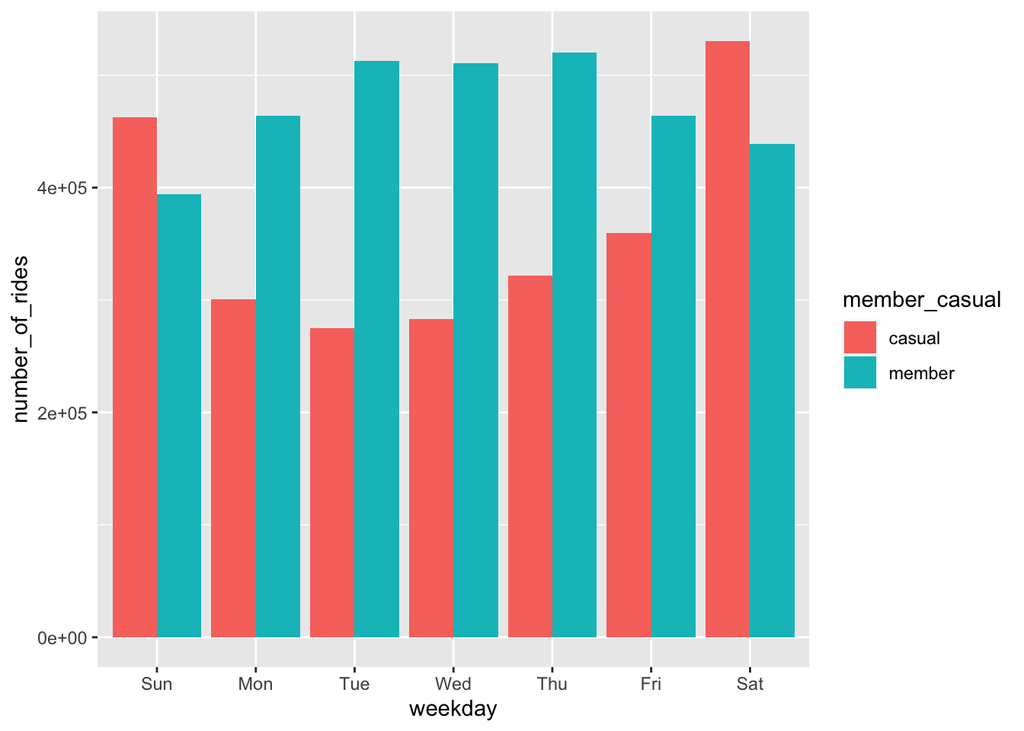

```r
trips_weekday %>% ggplot(aes(x = weekday, y = number_of_rides, fill = member_casual)) +
  geom_col(position = "dodge")
```

Do the same but with average duration for trips.

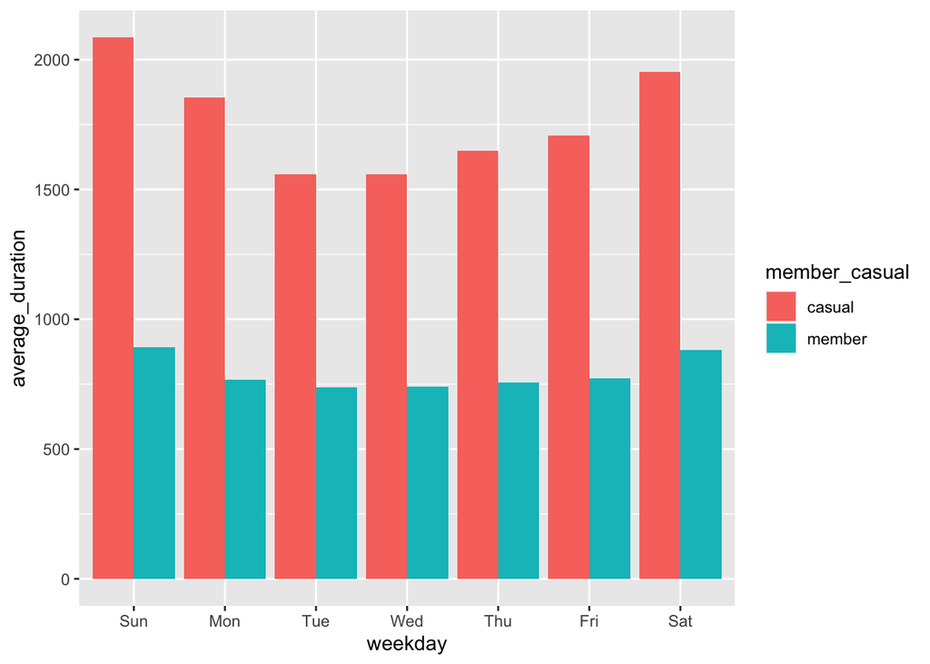

```r
trips_weekday %>% ggplot(aes(x = weekday, y = average_duration, fill = member_casual)) +
  geom_col(position = "dodge")
```

Now, let’s perform another data aggregation but this time use month as a parameter instead of weekday.

```r
trips_month <- yearly_trips %>%
  group_by(member_casual, month) %>%
  summarise(number_of_rides = n()
            ,average_duration = mean(ride_length)) %>%
  arrange(member_casual, month)
```

Make plots for this new dataset as well.

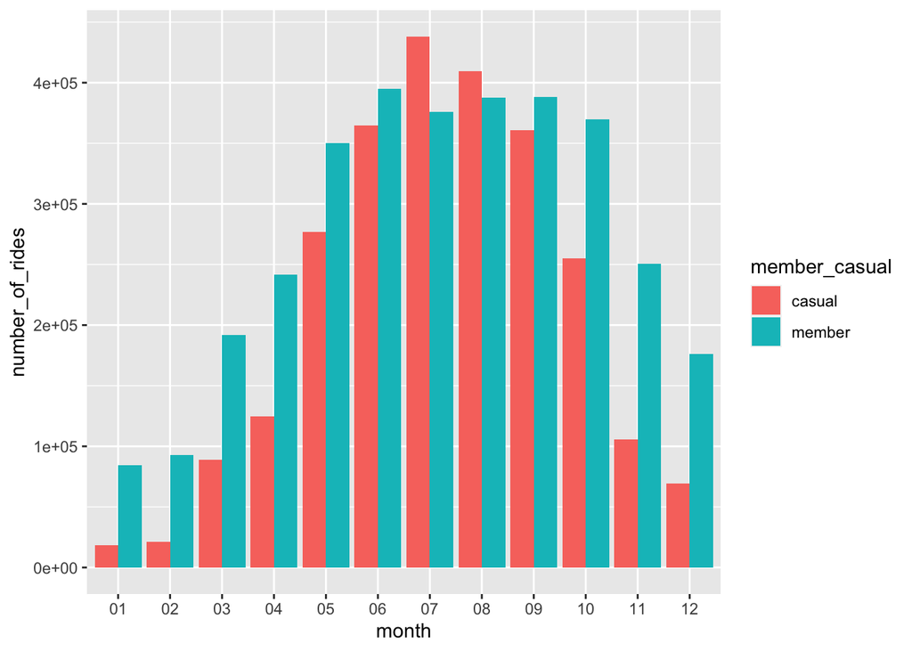

```r
trips_month %>% ggplot(aes(x = month, y = number_of_rides, fill = member_casual)) +
  geom_col(position = "dodge")
```

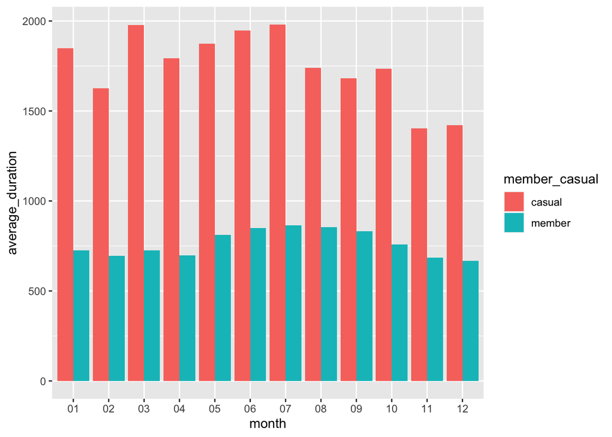

```r
trips_month %>% ggplot(aes(x = month, y = average_duration, fill = member_casual)) +
  geom_col(position = "dodge")
```

All done! Save the plots and proceed to share your data to gain more insigts.